# Analyzing SEO Practices: TRI and Industry Competitors

Author

Jarrod Griffin

Published

December 9, 2024

## Methodology and Input Companies’ Websites

#### Methodology

A reproducible research document was developed to systematically scrape and analyze websites from various competitors across six main types of webpages: **Index**, **About**, **Resources**, **App**, **Research**, and **Continuing Education Credits**. The table below details the inputs used for this analysis.

The process began by gathering the inputs, which included URLs corresponding to the six page types for each competitor. Each webpage was then scraped to extract **headings** and **title text**, resulting in a structured dataset containing these elements for TRI and its competitors.

Subsequently, text mining techniques were applied, focusing on **bi-gram frequency analysis**. Bi-grams (pairs of adjacent words) were generated from the headings and title text found on the webpages. This approach simulates the indexing process performed by search engines, providing insights into the terms and phrases prioritized by different organizations in their digital content.

The reproducible nature of this research document ensures that the analysis can be effortlessly rerun for any company with similar webpages. This flexibility makes it a valuable tool for benchmarking website content and SEO strategies within the context of competitive analysis. Please contact me(jarrod@jarrodgriffin.com or jsgriffin@cpp.edu) if any specific competitor or website should be added to the analysis.

|  | Company | Index | About | Resources | App | Research | Credits |
| --- | --- | --- | --- | --- | --- | --- | --- |
| 1 | TRI | https://www.traumaresourceinstitute.com | https://www.traumaresourceinstitute.com/about | https://www.traumaresourceinstitute.com/resources | https://www.traumaresourceinstitute.com/ichill | https://www.traumaresourceinstitute.com/research | https://www.traumaresourceinstitute.com/ces |
| 2 | Driven | https://home.hellodriven.com | https://home.hellodriven.com/about-us | https://home.hellodriven.com/resilience-resources | https://home.hellodriven.com/driven-app | https://home.hellodriven.com/research |  |
| 3 | Trauma Research Foundation | https://traumaresearchfoundation.org | https://traumaresearchfoundation.org/about/our-mission | https://traumaresearchfoundation.org/resources/trf-tuesday |  | https://traumaresearchfoundation.org/research/scientific-publications |  |
| 4 | Brainspotting | https://brainspotting.com | https://brainspotting.com/about-brainspotting | https://brainspotting.com/news |  | https://brainspotting.com/about-brainspotting/research-and-case-studies |  |
| 5 | Somatic Experiencing International | https://traumahealing.org | https://traumahealing.org/about | https://traumahealing.org/resources |  | https://traumahealing.org/research | https://traumahealing.org/continuing-education-credits |

## Assessment of TRI’s Current SEO Practice

### Index

The TRI homepage’s title text lacks specificity and does not effectively target important keywords related to their mission and services. While some critical keywords are incorporated into headings, such as those referencing the TRM model, there are notable omissions, including terms related to donations and continuing education credits, which could attract a broader audience. Additionally, some high-level headings are allocated to less relevant topics, such as legal and copyright information, which may dilute the SEO impact of more critical content. Optimizing these elements could significantly enhance the page’s search visibility and alignment with user intent.

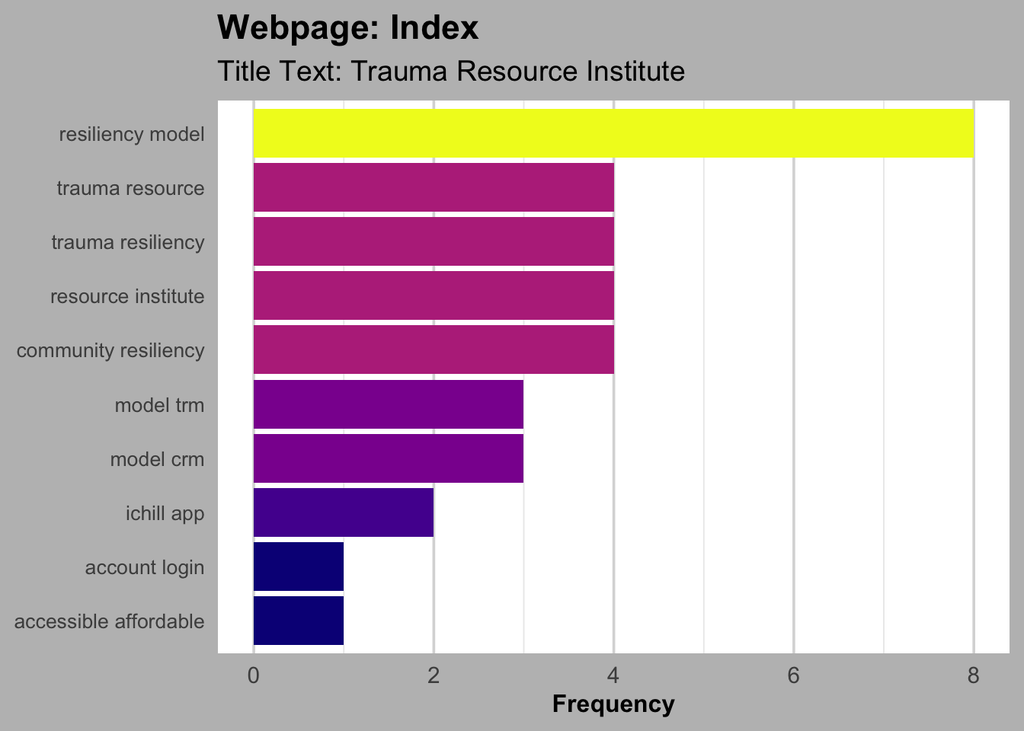

| h1 | h2 | h3 | h4 | h5 | h6 | titleText | URL |
| --- | --- | --- | --- | --- | --- | --- | --- |
| Build resilience | Humanitarian Response | The Trauma Resource Institute (TRI) is a nonprofit organization devoted to cultivating trauma-informed and resiliency-focused individuals and communities throughout the world. TRI is known internation… |  |  |  | Trauma Resource Institute | https://www.traumaresourceinstitute.com |
| Awaken hope | accessible, affordable, adaptable, transportable | The Trauma Resiliency Model (TRM)® and Community Resiliency Model (CRM)® are designed to help individuals understand the biology of traumatic stress reactions and learn specific skills to return the b… |  |  |  |  | https://www.traumaresourceinstitute.com |
| Trauma Resource Institute | Trauma Resiliency Model (TRM)® - for professionals and clinicians | The iChill app |  |  |  |  | https://www.traumaresourceinstitute.com |
| The Models | Community Resiliency Model (CRM)® - for communities | TRI is committed to expanding resiliency worldwide. We have a number of trainings and projects happening throughout the year, both domestically in the U.S. and internationally. |  |  |  |  | https://www.traumaresourceinstitute.com |
| Compassion without borders | Building resilience worldwide | TRI offers certifications in both the Community Resiliency Model and the Trauma Resiliency Model. While both models have been described as deceptively simple, there is a method to our model. We have a… |  |  |  |  | https://www.traumaresourceinstitute.com |
| Certified Practitioners | Help is available |  |  |  |  |  | https://www.traumaresourceinstitute.com |
| Latest News | Join our Community! |  |  |  |  |  | https://www.traumaresourceinstitute.com |
| Land Acknowledgment | Call us: (909) 626-4070 |  |  |  |  |  | https://www.traumaresourceinstitute.com |
|  | Learn More |  |  |  |  |  | https://www.traumaresourceinstitute.com |
|  | Our models |  |  |  |  |  | https://www.traumaresourceinstitute.com |

[output cut: 18 more lines]

### About

The About page features headings that are often too short and generic, making it difficult for key topics to stand out. While the page includes a variety of keywords, their potential SEO impact is diminished by the lack of clear and descriptive headings. Additionally, the title text is overly generic and fails to highlight essential aspects such as donations or continuing education credits, which could attract more targeted search traffic. Revising the headings and title text to include specific, keyword-rich descriptions could significantly improve the page’s visibility.

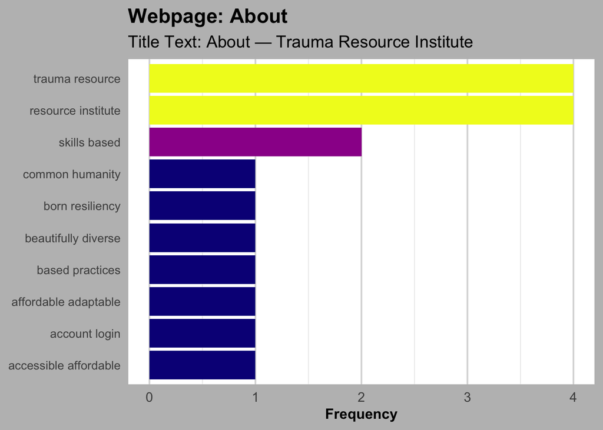

| h1 | h2 | h3 | h4 | h5 | h6 | titleText | URL |
| --- | --- | --- | --- | --- | --- | --- | --- |
| About | Join our Community! | Our Vision |  |  |  | About — Trauma Resource Institute | https://www.traumaresourceinstitute.com/about |
| Who we are... | Call us: (909) 626-4070 | To inspire a world where individuals and communities wholeheartedly embrace their common humanity and are empowered to nurture their inherent resiliency. |  |  |  |  | https://www.traumaresourceinstitute.com/about |
|  | Learn More | Our Mission |  |  |  |  | https://www.traumaresourceinstitute.com/about |
|  | Our models | The Trauma Resource Institute (TRI) is an international non-profit uplifting and empowering the global community through innovative ideas and skills, based on neuroscience and the wisdom of the body. |  |  |  |  | https://www.traumaresourceinstitute.com/about |
|  | Trainings | TRI fosters individual and systemic change by training individuals within a community across the lifespan in skills-based practices that are accessible, affordable, adaptable, and transportable. |  |  |  |  | https://www.traumaresourceinstitute.com/about |
|  | Job Opportunities | TRI recognizes the deep wisdom found in the tapestry of the beautifully diverse human family by cultivating both natural leaders and professionals. |  |  |  |  | https://www.traumaresourceinstitute.com/about |
|  |  | Our Beliefs |  |  |  |  | https://www.traumaresourceinstitute.com/about |
|  | Company | As a trauma educational organization we are committed to the following values: |  |  |  |  | https://www.traumaresourceinstitute.com/about |
|  | About | Every individual, child, and adult has a natural-born resiliency. |  |  |  |  | https://www.traumaresourceinstitute.com/about |
|  | Our Staff | When a traumatic event has resulted in symptoms, individuals are entitled to treatment that is gentle, effective, and culturally sensitive. |  |  |  |  | https://www.traumaresourceinstitute.com/about |

[output cut: 12 more lines]

### Resources

The Resources page could benefit from a longer and more descriptive title text that better communicates the purpose and value of the content offered. Currently, the page contains very few headings, which can result in key topics being overlooked or not fully understood by search engines. Additionally, much of the content is presented in a way that lacks proper categorization, making it less accessible to users and less likely to rank well for relevant searches. Implementing well-structured headings and organizing the content into clearly defined categories would enhance both SEO performance and user experience.

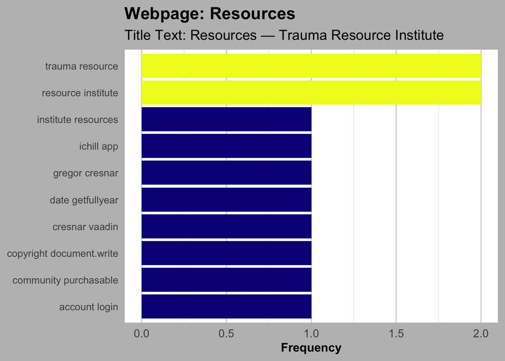

| h1 | h2 | h3 | h4 | h5 | h6 | titleText | URL |
| --- | --- | --- | --- | --- | --- | --- | --- |
| Resources | Join our Community! | Purchasable Resources |  |  |  | Resources — Trauma Resource Institute | https://www.traumaresourceinstitute.com/resources |
|  | Call us: (909) 626-4070 | Other Resources |  |  |  |  | https://www.traumaresourceinstitute.com/resources |
|  | Learn More |  |  |  |  |  | https://www.traumaresourceinstitute.com/resources |
|  | Our models |  |  |  |  |  | https://www.traumaresourceinstitute.com/resources |
|  | Trainings |  |  |  |  |  | https://www.traumaresourceinstitute.com/resources |
|  | Job Opportunities |  |  |  |  |  | https://www.traumaresourceinstitute.com/resources |
|  |  |  |  |  |  |  | https://www.traumaresourceinstitute.com/resources |
|  | Company |  |  |  |  |  | https://www.traumaresourceinstitute.com/resources |
|  | About |  |  |  |  |  | https://www.traumaresourceinstitute.com/resources |
|  | Our Staff |  |  |  |  |  | https://www.traumaresourceinstitute.com/resources |

[output cut: 12 more lines]

### App

The iChill app page provides valuable information about the app’s capabilities and how it helps users, but it is underutilized in terms of SEO. The lack of headings on the page presents a missed opportunity to incorporate additional keywords that highlight the app’s features and benefits. By creating descriptive headings for each feature or benefit, the page could improve its search engine visibility and better align with user intent. Structured headings would also enhance the user experience by making the content more navigable and engaging.

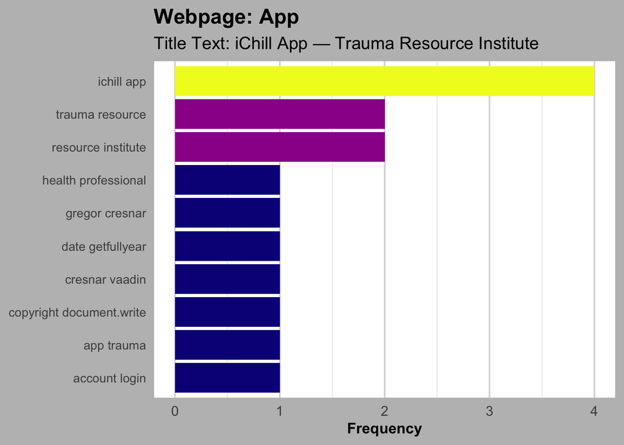

| h1 | h2 | h3 | h4 | h5 | h6 | titleText | URL |
| --- | --- | --- | --- | --- | --- | --- | --- |
| iChill App | back to TRI Resources | iChill App |  |  |  | iChill App — Trauma Resource Institute | https://www.traumaresourceinstitute.com/ichill |
|  | iChill is not meant as a substitute for counseling with a licensed mental health professional. |  |  |  |  |  | https://www.traumaresourceinstitute.com/ichill |
|  | Join our Community! |  |  |  |  |  | https://www.traumaresourceinstitute.com/ichill |
|  | Call us: (909) 626-4070 |  |  |  |  |  | https://www.traumaresourceinstitute.com/ichill |
|  | Learn More |  |  |  |  |  | https://www.traumaresourceinstitute.com/ichill |
|  | Our models |  |  |  |  |  | https://www.traumaresourceinstitute.com/ichill |
|  | Trainings |  |  |  |  |  | https://www.traumaresourceinstitute.com/ichill |
|  | Job Opportunities |  |  |  |  |  | https://www.traumaresourceinstitute.com/ichill |
|  |  |  |  |  |  |  | https://www.traumaresourceinstitute.com/ichill |
|  | Company |  |  |  |  |  | https://www.traumaresourceinstitute.com/ichill |

[output cut: 14 more lines]

### Research

The Research page includes headings, but they could be more effective by incorporating topic tags before each research title. This approach would allow for the addition of targeted keywords, enhancing the page’s SEO performance in key areas. While the page contains a substantial amount of valuable content, organizing it around consistent topics would improve its focus and make it more accessible to both search engines and users. Clear and structured categorization of research topics would also help raise awareness of TRI’s expertise and contributions in specific fields.

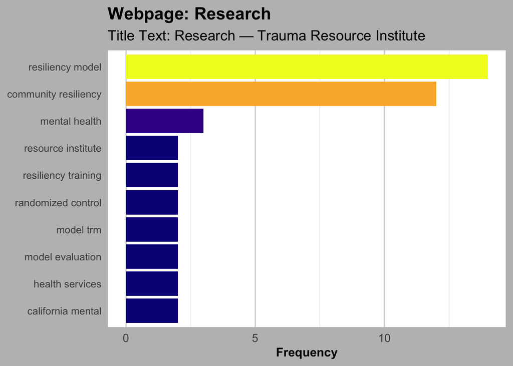

| h1 | h2 | h3 | h4 | h5 | h6 | titleText | URL |
| --- | --- | --- | --- | --- | --- | --- | --- |
| Research | Document last updated: November 2022 | Research is an important tool for establishing the effectiveness of any intervention. Our Community Resiliency Model (CRM)® is evidence-based and based on cutting-edge neuroscience. We are pleased to … |  |  |  | Research — Trauma Resource Institute | https://www.traumaresourceinstitute.com/research |
|  | Brief Report | VARIOUS MEASURES |  |  |  |  | https://www.traumaresourceinstitute.com/research |
|  | Randomized Control Trial Study | PUBLISHED RESEARCH |  |  |  |  | https://www.traumaresourceinstitute.com/research |
|  | Join our Community! | Navigating Challenges: The Impact of Community Resiliency Model Training on Nurse Leaders |  |  |  |  | https://www.traumaresourceinstitute.com/research |
|  | Call us: (909) 626-4070 | Pilot Study of a Resiliency Based and Trauma Informed Intervention for Veterans |  |  |  |  | https://www.traumaresourceinstitute.com/research |
|  | Learn More | Building Resilience and Improving Wellbeing in Sierra Leone Using the Community Resiliency Model Post Ebola |  |  |  |  | https://www.traumaresourceinstitute.com/research |
|  | Our models | The Community Resiliency Model, An Interoceptive Awareness Tool to Support Population Mental Wellness |  |  |  |  | https://www.traumaresourceinstitute.com/research |
|  | Trainings | Practical Resiliency Training for Healthcare Workers During COVID-19: Results from a Randomised Controlled Trial Testing the Community Resiliency Model for Well-being Support |  |  |  |  | https://www.traumaresourceinstitute.com/research |
|  | Job Opportunities | Role of Community Resiliency Model Skills Training in Trauma Healing Among 1994 Tutsi Genocide Survivors in Rwanda |  |  |  |  | https://www.traumaresourceinstitute.com/research |
|  |  | Exploring the Usability of a Community Resiliency Model Approach in a High Need/Low Resourced Traumatized Community |  |  |  |  | https://www.traumaresourceinstitute.com/research |

[output cut: 15 more lines]

### Continuing Education Credits

The Continuing Education Credits page follows a similar pattern of having few, limited headings, which restricts its SEO potential. The lack of descriptive and keyword-rich headings makes it difficult for important topics to stand out and be effectively indexed by search engines. Incorporating detailed headings that highlight key aspects such as accreditation, eligible professions, and benefits of the credits could significantly enhance the page’s visibility. By structuring the content with more targeted topics and keywords, the page could better attract and inform its intended audience.

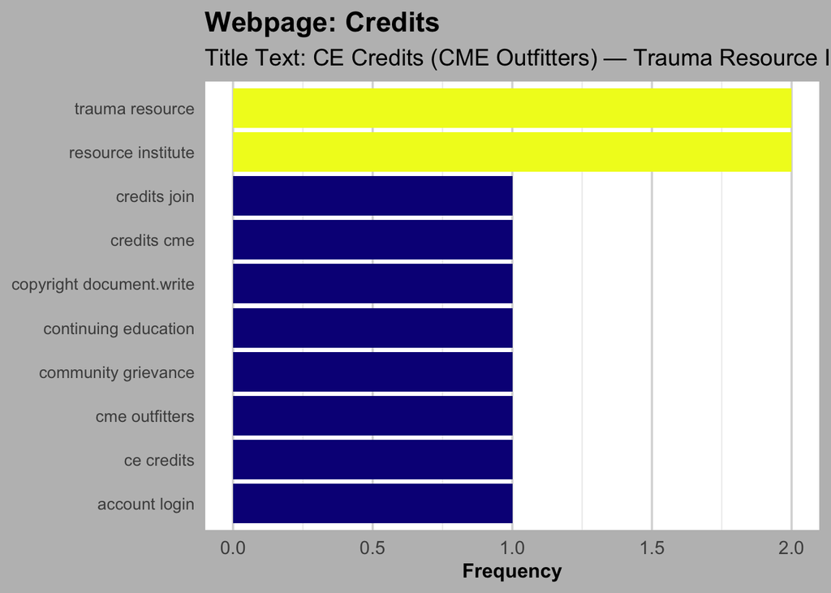

| h1 | h2 | h3 | h4 | h5 | h6 | titleText | URL |
| --- | --- | --- | --- | --- | --- | --- | --- |
| Continuing Education Credits | Join our Community! | Grievance Policy |  |  |  | CE Credits (CME Outfitters) — Trauma Resource Institute | https://www.traumaresourceinstitute.com/ces |
|  | Call us: (909) 626-4070 | Accommodations for the differently abled |  |  |  |  | https://www.traumaresourceinstitute.com/ces |
|  | Learn More | Disclosure Declaration |  |  |  |  | https://www.traumaresourceinstitute.com/ces |
|  | Our models | Unlabeled Use Disclosure |  |  |  |  | https://www.traumaresourceinstitute.com/ces |
|  | Trainings |  |  |  |  |  | https://www.traumaresourceinstitute.com/ces |
|  | Job Opportunities |  |  |  |  |  | https://www.traumaresourceinstitute.com/ces |
|  |  |  |  |  |  |  | https://www.traumaresourceinstitute.com/ces |
|  | Company |  |  |  |  |  | https://www.traumaresourceinstitute.com/ces |
|  | About |  |  |  |  |  | https://www.traumaresourceinstitute.com/ces |
|  | Our Staff |  |  |  |  |  | https://www.traumaresourceinstitute.com/ces |

[output cut: 12 more lines]

## Competitive Analysis

### Index

The homepage serves as a crucial introduction to the company, offering an overview of its mission and services. TRI excels in this area, presenting a well-rounded and informative snapshot of its offerings, positioning itself strongly in search engine rankings. Driven also performs well, providing competitive content and structure. However, Brainspotting and the Trauma Research Foundation fall short, with less comprehensive homepages that fail to effectively convey their value propositions, reflected in their weaker search engine performance. TRI’s strong homepage sets a benchmark for competitors, emphasizing the importance of clear and engaging content for SEO success.

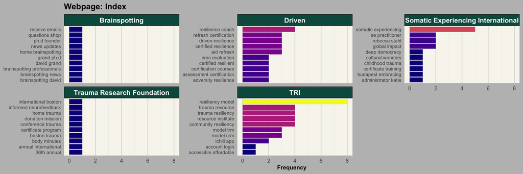

### About

The About page serves as an opportunity to showcase what the business offers and how it operates. TRI performs well in this area, effectively highlighting its key services and mission. However, competitors like Driven stand out by incorporating more educationally focused keywords, which align closely with their target audience’s interests. In contrast, other companies lack specificity, missing the chance to clearly communicate their unique value propositions and connect with user search intent.

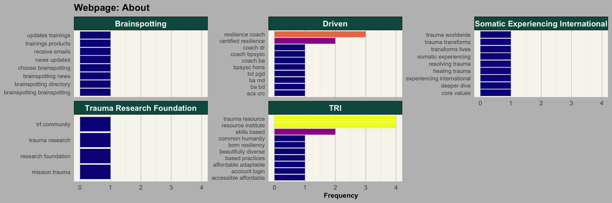

### Resources

TRI falls behind some competition on the Resources page, as it relies on short, generic, and uninformative headings that fail to clearly represent the resources it offers. This lack of clarity diminishes the page’s effectiveness in highlighting TRI’s unique value. While no competitor excels in this area, Driven stands out for its strong emphasis on resilience-focused resources, offering a more targeted and robust approach that better aligns with audience needs.

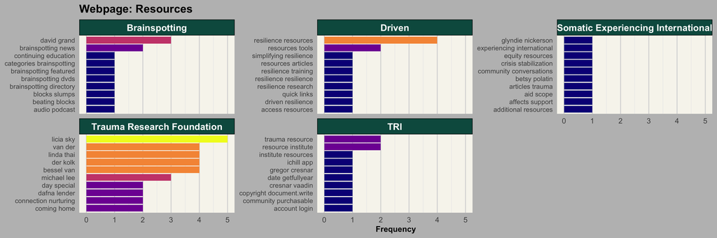

### App

The TRI app page places clear emphasis on the application’s name, which helps with branding, but it falls short by not providing sufficient details about what the application does. This lack of feature descriptions limits its ability to engage users and reduces its discoverability by search engines. In contrast, the Driven app page is well-executed, offering a comprehensive overview of the app’s features, which enhances both user understanding and SEO performance. TRI can improve by including detailed descriptions of the app’s functionality, organized under descriptive headings, to better compete and align with user expectations.

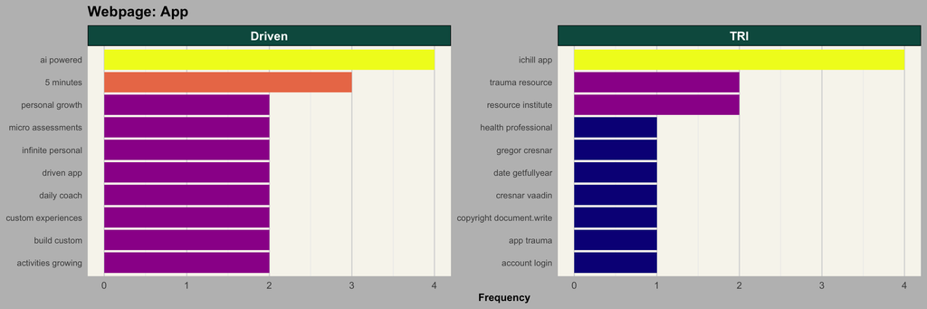

### Research

The research pages highlight the impact of having extensive content, as competitors with more comprehensive pages perform significantly better. Across almost all competitors, there is a noticeable increase in the diversity and volume of topics covered, which enhances their visibility and engagement. Driven stands out as the strongest performer, offering a wide range of varied topics that cater to different audience interests and improve SEO rankings. This demonstrates the value of well-organized, content-rich pages in driving search engine success and audience engagement. TRI could benefit from expanding and diversifying its research headings to remain competitive.

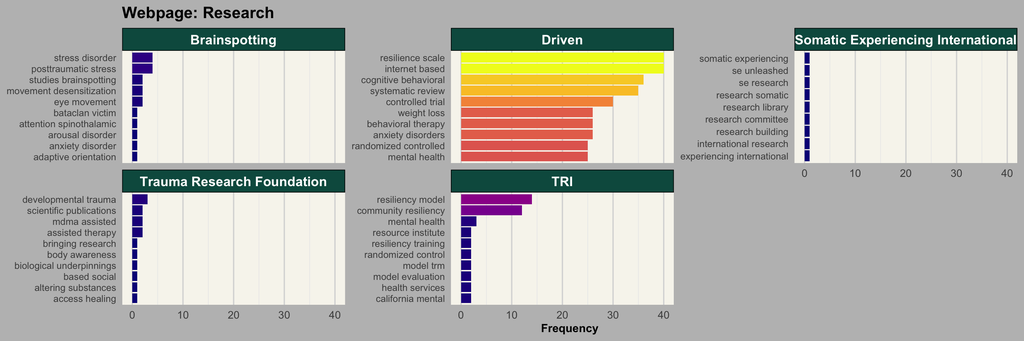

### Continuing Education Credits

Somatic Experiencing International excels in presenting continuing education credits, setting a high standard that may be challenging to compete with. However, the presence of a dedicated continuing education credit page is relatively uncommon among competitors, presenting an opportunity for TRI to differentiate itself. By enhancing its page with detailed, keyword-rich content that highlights the benefits and specifics of continuing education credits, TRI could position itself as a leader in this niche and attract a broader audience seeking professional development opportunities.

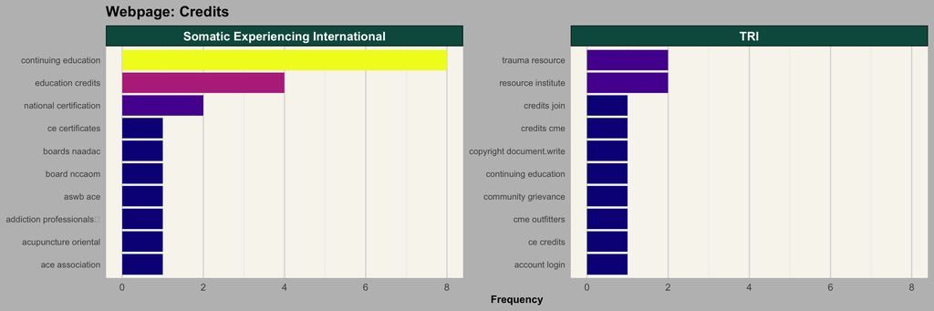

## Recommended SEO Strategy

Overall, TRI should prioritize improving its website layout, with a strong focus on optimizing headings and webpage title text. These elements are currently underutilized, limiting the site’s ability to effectively communicate its value and rank well in search engine results. Enhancing the structure and specificity of headings across all pages, coupled with more descriptive and keyword-rich title text, will significantly boost SEO performance. Below, I outline tailored topics and targeted keywords for each TRI webpage to help enhance visibility and engagement with the intended audience.

### Index

#### SEO Topics

1. **Trauma Resiliency Model (TRM) Training**
   - Detailed overview of TRM training programs for clinicians and professionals.
   - Benefits of TRM in addressing traumatic stress reactions.
2. **Continuing Education for Mental Health Professionals**
   - Availability of Continuing Education (CE) credits through TRM courses.
   - Accreditation and certification details for professionals.
3. **Community Resiliency Initiatives**
   - Programs aimed at training community leaders in trauma-informed care.
   - Success stories of community resilience building.
4. **Partnerships with Professional Associations**
   - Collaborations with organizations like the American Psychological Association (APA).
   - Joint webinars, events, and training sessions.
5. **Digital Resources and Tools**
   - Introduction to the iChill app and its features.
   - Online materials and webinars available for self-paced learning.

#### Targeted Keywords

- Trauma Resiliency Model training
- TRM course for clinicians
- Continuing education credits for mental health professionals
- Trauma-informed care training
- Community Resiliency Model programs
- Mental health professional development
- iChill app for stress management
- Partnerships with APA
- Online trauma recovery resources
- Resilience training for community leaders

### About

#### SEO Topics

1. **Overview of the Trauma Resiliency Model (TRM)**
   - Detailed description of TRM and its applications in trauma recovery.
   - Benefits of TRM for mental health professionals and community leaders.
2. **Mission and Vision of the Trauma Resource Institute**
   - Commitment to empowering communities through neuroscience-based skills.
   - Dedication to accessible, donation-enabled, and culturally sensitive trauma interventions.
3. **Global Impact Through Donation-Supported Trainings**
   - Highlight TRI’s efforts to provide training funded through donations.
   - Showcase success stories of how donations have enabled community training programs worldwide.
4. **Professional Training and Continuing Education**
   - TRM training opportunities for clinicians and professionals.
   - Availability of Continuing Education (CE) credits through TRI courses.
5. **Innovative Tools and Resources**
   - Introduction to the iChill app and its role in stress management.
   - Access to online materials and webinars for ongoing learning.
6. **Supporting TRI’s Mission Through Donations**
   - Emphasize how donations help fund trauma recovery training programs.
   - Provide clear calls to action for supporting TRI’s initiatives.

#### Targeted Keywords

- Trauma Resiliency Model overview
- TRM benefits for mental health professionals
- Donation-supported trauma training programs
- Community resilience training programs
- Neuroscience-based trauma interventions
- Accessible trauma recovery resources
- Continuing education credits for clinicians
- Global trauma training initiatives
- iChill app for stress management
- Culturally sensitive trauma care
- Professional development in trauma recovery
- Donate to support trauma training
- Fund community resilience programs

### Resources

#### SEO Topics

1. **Comprehensive Trauma Recovery Materials**
   - Overview of purchasable resources, including TRM workbooks and merchandise.
   - Access to specialized trainings and webinars for in-depth learning.
2. **Innovative Tools for Stress Management**
   - Introduction to the iChill app and its features for managing stress and trauma responses.
   - Guidance on integrating the app into daily wellness routines.
3. **Free Educational Resources**
   - Availability of free recordings and webinars on trauma resiliency and community support.
   - Insights from the “Resiliency Within” podcast by Elaine Miller-Karas.
4. **Professional Development Opportunities**
   - Information on TRI certification programs for CRM/TRM.
   - Details on Continuing Education (CE) credits available through CME Outfitters.
5. **Community Engagement and Support**
   - Resources for finding trained therapists specializing in trauma recovery.
   - Opportunities to get involved with TRI’s mission through donations and participation.

#### Targeted Keywords

- Trauma Resiliency Model resources
- TRM training materials
- Specialized trauma webinars
- iChill app for stress relief
- Free trauma recovery recordings
- Resiliency Within podcast
- CRM/TRM certification programs
- Continuing Education credits for mental health professionals
- Find a trauma therapist
- Donate to support trauma training

### App

#### SEO Topics

1. **Introduction to the iChill App**
   - Overview of iChill as a free resource for stress and trauma management.
   - Explanation of the six wellness skills from the Trauma Resiliency Model (TRM)® and Community Resiliency Model (CRM)® taught within the app.
2. **Features and Benefits of iChill**
   - How iChill helps users return to their “Okay Zone” by managing sensations associated with trauma and stress.
   - Benefits for children, teens, and adults in reducing anxiety and depression symptoms.
3. **User Experience Enhancements**
   - Details about the app’s availability in multiple languages, including English, Arabic, Spanish, Hebrew, and Ukrainian.
   - Information on the updated interface and new features like adjustable audio speed and personalized resources.
4. **Accessibility and Availability**
   - Instructions for downloading iChill on iOS and Android platforms.
   - Accessing iChill online for users without smartphone access.
5. **Supporting Mental Health Through Technology**
   - The role of iChill in complementing professional mental health services.
   - Encouraging donations to support the development and maintenance of free mental health resources like iChill.

#### Targeted Keywords

- iChill app for stress management
- Trauma Resiliency Model wellness skills
- Community Resiliency Model techniques
- Free mental health app
- Manage anxiety and depression with iChill
- Multilingual stress relief app
- Download iChill for iOS and Android
- Online access to iChill app
- Complementary tool for mental health professionals
- Donate to support free mental health resources

### Research

#### SEO Topics

1. **Evidence-Based Trauma Interventions**
   - Overview of the Community Resiliency Model (CRM)® and Trauma Resiliency Model (TRM)® as evidence-based practices.
   - Summaries of research studies validating the effectiveness of CRM and TRM.
2. **Published Research and Findings**
   - Highlights of peer-reviewed articles and studies featuring TRI’s models.
   - Links to publications demonstrating the impact of CRM and TRM on various populations.
3. **Ongoing Research Collaborations**
   - Information on current randomized control trials at institutions like Emory University, Claremont Graduate University, and Loma Linda University.
   - Details about partnerships with universities and research organizations.
4. **Global Impact of TRI’s Models**
   - Case studies showcasing the application of CRM and TRM in diverse communities worldwide.
   - Success stories illustrating the models’ effectiveness in different cultural contexts.
5. **Research Resources and Tools**
   - Access to a curated list of measures and tools used in TRI-related research.
   - Guidance on utilizing these resources for independent studies.

#### Targeted Keywords

- Community Resiliency Model research
- Trauma Resiliency Model studies
- Evidence-based trauma interventions
- CRM and TRM effectiveness
- Published research on trauma recovery
- Randomized control trials on CRM
- Global impact of resiliency models
- Trauma intervention case studies
- Research collaborations in trauma care
- Trauma recovery research resources

### Continuing Education Credits

#### SEO Topics

1. **Accredited Continuing Education Opportunities**
   - Overview of CE credits offered through TRI’s training programs.
   - Details on co-sponsorship with the American Psychological Association (APA) Office of Continuing Education in Psychology (CEP).
2. **Professional Development for Healthcare Providers**
   - Information on joint accreditation by the Accreditation Council for Continuing Medical Education (ACCME), Accreditation Council for Pharmacy Education (ACPE), and American Nurses Credentialing Center (ANCC).
   - Opportunities for social workers, nurses, physicians, and other healthcare professionals to earn CE credits.
3. **Accessible Training Facilities**
   - Commitment to compliance with the Americans with Disabilities Act.
   - Provision of accommodations for individuals with sensory impairments.
4. **Grievance and Disclosure Policies**
   - Outline of grievance procedures to ensure equitable treatment.
   - Transparency in faculty disclosures and conflict of interest resolutions.
5. **Specialized Training Programs**
   - Availability of Trauma Resiliency Model (TRM)® and Community Resiliency Model (CRM)® trainings offering CE credits.
   - Schedules and registration information for upcoming training sessions.

#### Targeted Keywords

- Continuing Education credits for mental health professionals
- APA-approved CE programs
- Accredited trauma training courses
- Professional development in trauma resiliency
- CE opportunities for social workers and nurses
- TRM and CRM training with CE credits
- Accessible training facilities for CE courses
- Grievance policy for continuing education programs
- Faculty disclosure in CE activities
- Jointly accredited CE programs for healthcare providers